# Ising Model

Ising model is one of the more famous models in statistical physics. The system studied in the model has 'spins' located at vertices of a (possibly infinite) lattice, and spins interact with their neighbours using a specific rule (like spins stabilize the energy and unlike spins destabilize the energy) and iteract with external field B; thus the energy of the system is given as: $$ U = - \sum_i B\sigma_i - \frac{1}{2} \sum_{\langle i,j \rangle} J \sigma_i \sigma_j $$ In the simple version of the model, $\sigma_i = \pm 1$, and system is maintained at temperature $T$; the probability of a particular configuration is given by the Boltzmann Probability Law: $$ P(\{\sigma_i\}_{i=1}^N) \propto \exp\left[-\beta U(\{\sigma_i\})\right] $$

Clearly the probability is then given by $$ P(\{ \sigma_i\}_{i=1}^N) \propto \exp\left[ \frac{B}{kT} \sum_i \sigma_i + \frac{J}{2kT}\sum_{\langle i,j\rangle} \sigma_i \sigma_j \right] $$ and hence depends on numerical values of $\frac{B}{kT}$ and $\frac{J}{2kT}$.

## Periodic Boundary Conditions

To simulate a infinite system, it is common to use Periodic Boundary Conditions (PBC). As illustraition consider 1-dimensional (1D) lattice, which is nothing but a straight line, with $N$ spins placed with equal spacing between two contigious spins. This chain of spins has left-end and right-end making this a finite system; however if we place this chain of spins on a circle such that in addition to requiring that distance between contigious spins is 1 unit, we require the distance betwen left-end and right-end of chain is 1 unit. We now see that the chain becomes *infinite*.

You can imagine similar trick in 2 dimensions, by requiing PBC in x-direction and y-directions. And, in 3-dimensions, requiring PBC in x-direction, y-direction and z-directions.

### A specific trick applicable only for Ising Model for periodic boundary conditions

Add one extra row and one extra column to the configuration; the additional column/row is the copy of first column/row.

## For Ising model, write following functions. Assume 2-dimensional model.

Set $J=1$ without loss of generality. See http://web.mit.edu/krish_s/www/files/ising_Model.pdf page-27 has $m\, vs\, T$ plot

```python
import numpy as np
import matplotlib.pyplot as plt
import math
import random
```

```python
class Ising2D:

    def __init__(self, pbcx, pbcy, **kwargs):
        config = None
        if kwargs:
            config = kwargs['config']
        self.pbcx = pbcx
        self.pbcy = pbcy
        self.model = np.random.choice([1], size=(self.pbcy, self.pbcx))
        if config:
            self.model = config
        self.N = pbcx*pbcy
        self.ens = None
        self.B = 0
        self.J = 1
        self.kT = 1
        self.mu = 1

    def energy (self):
        n = self.pbcy
        m = self.pbcx
        ar = self.model
        ps = 0
        ts = np.sum(ar)
        for i in range(0, n):
            for j in range(0, m):
                ps += ar[(i-1)%n][j%m]
                ps += ar[(i+1)%n][j%m]
                ps += ar[i%n][(j-1)%m]
                ps += ar[i%n][(j+1)%m]
        E = (-ts*self.B) - (0.5*self.J*ps)
        N = n*m
        self.ens = (E, ts, ps)
        return (E, ts, ps)

    def magnetisation (self):
        #model = Ising2D_Energy(B, J, self.pbcx, self.pbcy)
        n = self.pbcy
        m = self.pbcx
        #print(m,n)
        return (self.mu*np.sum(self.model)/(m*n))

    def MC_SingleSpinFlip(self,T):

        ar = self.model
        n = self.pbcy
        m = self.pbcx

        # Select spin at random
        y = np.random.randint(0, m, dtype=int)
        x = np.random.randint(0, n, dtype=int)
        ar[x][y]=-ar[x][y]
        self.model=ar
        sum_around=ar[(x+1)%n][y]+ar[x][(y+1)%m]+ar[(x-1)%n][y]+ar[x][(y-1)%m]
        delE=-2*ar[x][y]*(self.B+sum_around*self.J)
        p_acc = math.exp(-delE/T)
        if np.random.random() >=p_acc:
            ar[x][y]=-ar[x][y]

    def Heat_capacity(self,T):
        a=[];
        b=[];
        for i in range(1000):
            self.MC_SingleSpinFlip(T)
            temp=self.energy()[0];
            a.append(temp);
            b.append(temp**2);
        avg_E2=(np.sum(b)/1000);
        avg_E=(np.sum(a)/1000);
        return (avg_E2-avg_E**2)/(T**2)

    pass
```

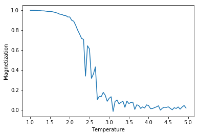

```python
mod1 = Ising2D(20,20)
#print(mod1.energy())
#print(mod1.magnetisation())
#print(mod1.MC_SingleSpinFlip(20))
a=[]
b=[]
c=np.arange(1,5,0.05)
for j in c:
    for i in range(50000):
        mod1.MC_SingleSpinFlip(j)
        a.append(mod1.magnetisation())
    b.append(np.sum(a)/50000)
    a=[]
    mod1=Ising2D(20,20)
plt.plot(c,b)
plt.xlabel("Temperature")
plt.ylabel("Magnetization")
```

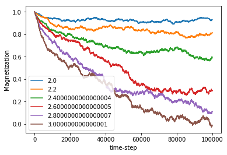

```python
a=[]
c=np.arange(2,3.1,0.2)
for i in c:
    mod1=Ising2D(50,50)
    for j in range(100000):
        mod1.MC_SingleSpinFlip(i)
        a.append(mod1.magnetisation())
    plt.plot(range(100000),a,label=str(i))
    plt.legend()
    plt.xlabel("time-step")
    plt.ylabel("Magnetization")
    a=[]
```

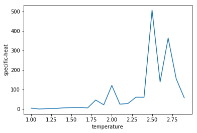

```python
a=[]
c=np.arange(1,3,0.1)
mod2=Ising2D(20,20)
for i in c:
    a.append(mod2.Heat_capacity(i))
plt.plot(c,a)
plt.ylabel("specific-heat")
plt.xlabel("temperature")
```